# Reltrad in the United States, 1972 - 2016

David Eagle, PhD

2019-01-15

## Religious Affiliation According to *Reltrad*

### How the United States has Changed Religiously 1972-2016

I have generated the code to create the *reltrad* variable in the General Social Survey. In this post, I use this variable to plot how religious affiliation has changed in the United States.

In the R code below, I use the package [*srvyr*](https://cran.r-project.org/web/packages/srvyr/srvyr.pdf) to use *dplyr*-like syntax to create a weighted survey object.

The data are available on Github and were created with my reltrad [script](https://github.com/thebigbird/R_Stata_Reltrad/blob/master/ReltradGSS.R).

```r
#The recoded data are loaded
gss=read.csv("https://github.com/thebigbird/R_Stata_Reltrad/blob/master/gss7216_reltrad.csv?raw=true")
```

```r
library(tidyverse)
library(srvyr)

gssSvy <-  gss %>%  as_survey_design(ids = 1, weights = wtssall)

#Grouping by year and reltrad. survey_mean calculates proportions of factor variables
#when an argument is not used.
relTable = gssSvy %>% group_by(year, reltrad) %>%
  summarize(proportion = survey_mean(na.rm=T, proportion=T))
#for the error bars
relTable = relTable %>% mutate(ymin = proportion - 1.96*proportion_se,
                               ymax = proportion + 1.96*proportion_se)
#Reorder the factors so they appear in same order on the legend and the plot
relTable$reltrad <- factor(relTable$reltrad, levels =
                             c("Roman Catholic", "Mainline Protestant",
                               "Conservative Protestant", "Black Protestant", "None",
                               "Other", "Jewish"),
                            labels =
                             c("Roman Catholic", "Mainline Protestant",
                               "Conservative Protestant", "Black Protestant","None",
                               "Other", "Jewish"))

#Get rid of NA's in reltrad
relTable = relTable[!is.na(relTable$reltrad),]
```

Now, using the magic of *ggplot2* I generate a plot of how religious affiliation has changed in the United States from 1972 to 2016.

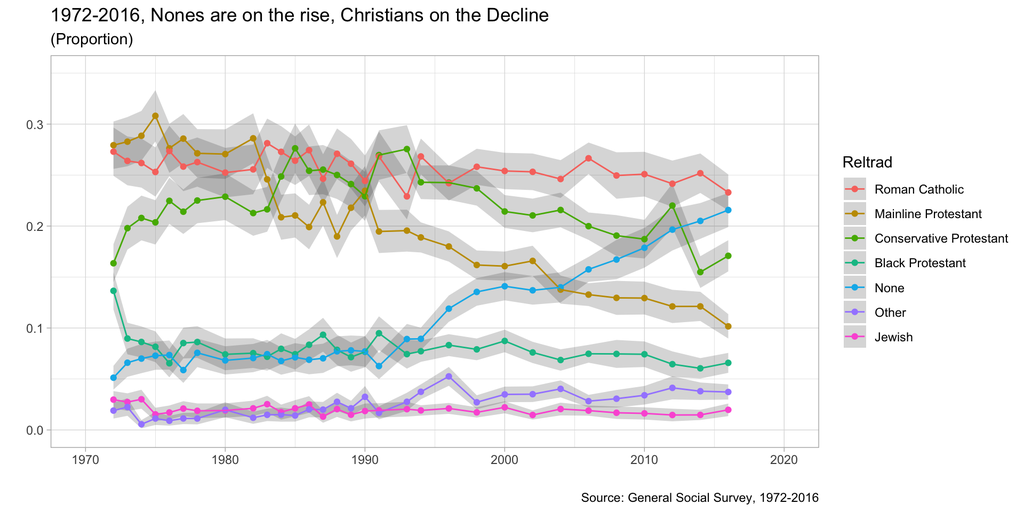

```r
ggplot(data = relTable, aes(x=year, y=proportion, ymin = ymin, ymax = ymax, color = reltrad)) +
  geom_ribbon(alpha = .2, linetype = 0) + geom_point() + geom_line() +
  ylab("") + xlab("") +
  scale_x_continuous(limits=c(1970, 2020)) +
  scale_y_continuous(limits=c(0, .35)) +
  scale_color_discrete("Reltrad")+
  theme_light() +
 labs(title = "1972-2016, Nones are on the rise, Christians on the Decline",
      subtitle = "(Proportion)",
      caption = "Source: General Social Survey, 1972-2016")
```

A few notable trends are evident in this plot. First of all, the proportion of Roman Catholics in the United States has stayed relatively steady over this period. While Latin American immigration has brought a lot of new Catholics to the United States, this has been offset by losses among the non-hispanic Catholic population.

The higher proportion Black Protestant in 1972 is probably due to some sort of artifact in the GSS data. There seems to be a lower proportion of Conservative Protestants that year as well. This blip is also found on other plots of GSS reltrad data, [here](https://thesocietypages.org/ccf/2014/07/09/religious-change/fig-2-religious-change/), for example.

Also important is that the “Other” religion category is steadily climbing, and has reached a high of about 5% of the US population. The proportion of the population identifying as Black Protestants remained fairly steady over this period, but recently has begun to decline.